# Online Shoppers purchase Intention analysis

```r
C(dat1,n_customerbehave,3,dat1$ExitRates,dat1$BounceRates,"ExitRates","BounceRates")
```

```
##
##     new_customer not_interseted_customer target_customer
##   1           37                     872              63
##   2         1204                    7288            1823
##   3           31                     921               6
```

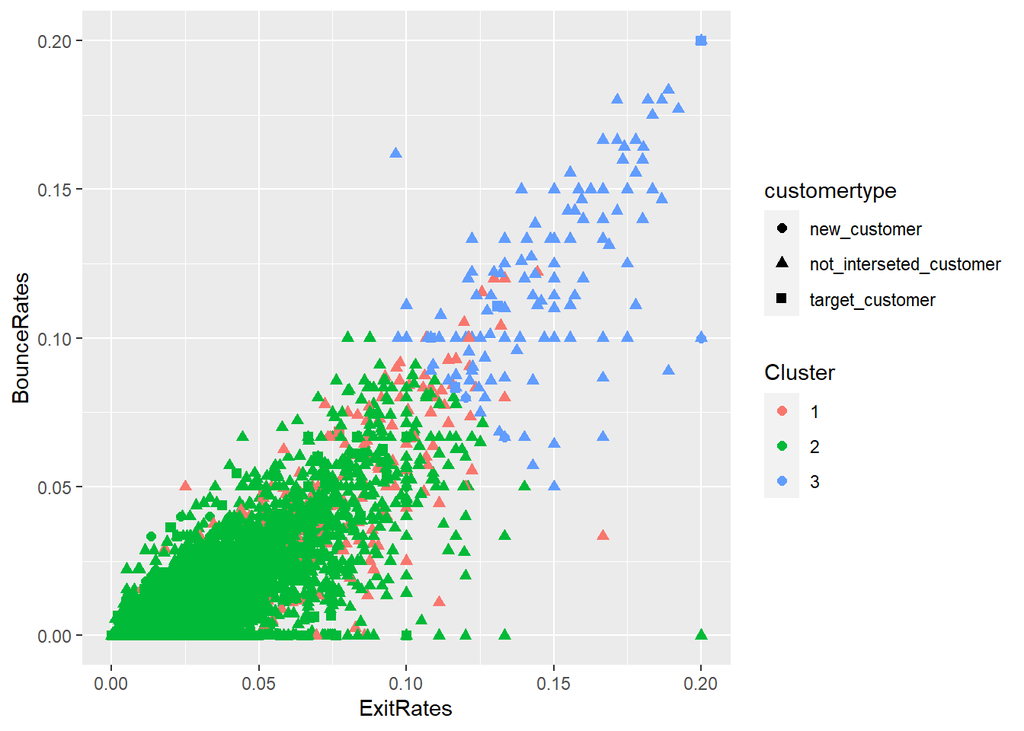

```r
C(dat1,n_customerbehave,3,dat1$ProductRelated,dat1$BounceRates,"ProductRelated","PageValuess")
```

```
##
##     new_customer not_interseted_customer target_customer
##   1           37                     872              63
##   2         1204                    7288            1823
##   3           31                     921               6
```

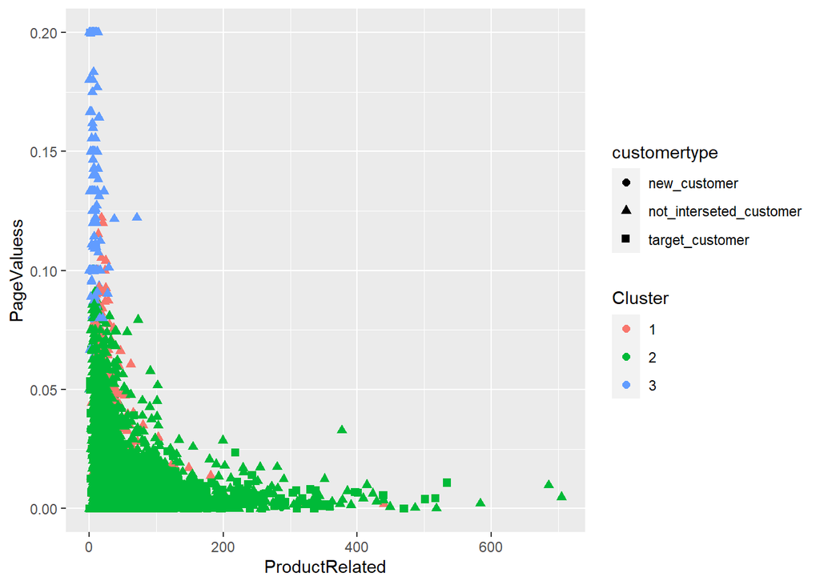

```r
C(dat1,n_customerbehave,3,dat1$Informational,dat1$BounceRates,"Informational","PageValues")
```

```
##
##     new_customer not_interseted_customer target_customer
##   1           37                     872              63
##   2         1204                    7288            1823
##   3           31                     921               6
```

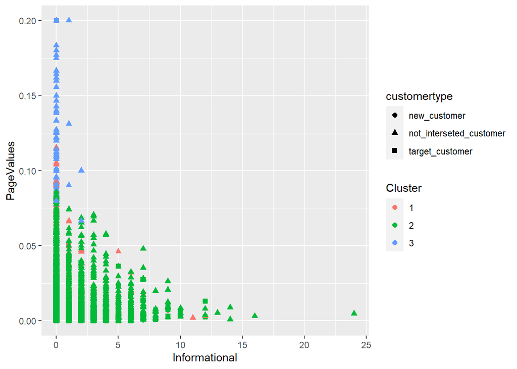

```r
C(dat1,n_customerbehave,3,dat1$Administrative,dat1$BounceRates,"Administrative","PageValues")
```

```
##
##     new_customer not_interseted_customer target_customer
##   1           37                     872              63
##   2         1204                    7288            1823
##   3           31                     921               6
```

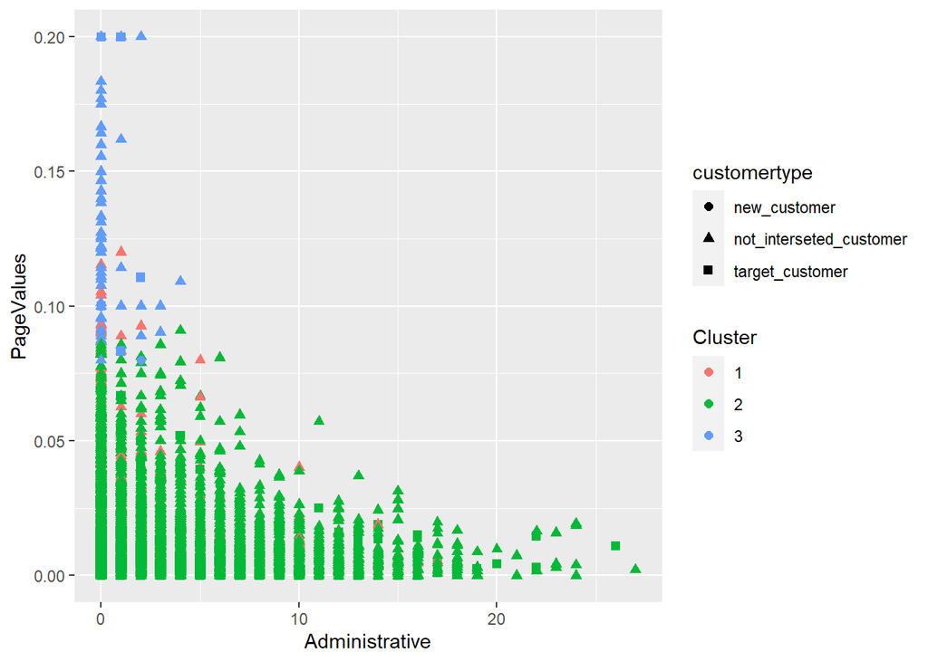

```r
C(dat1,n_customerbehave,3,dat1$ProductRelated_Duration,dat1$SpecialDay,"ProductRelated_Duration","SpecialDay")
```

```
##
##     new_customer not_interseted_customer target_customer
##   1           37                     872              63
##   2         1204                    7288            1823
##   3           31                     921               6
```

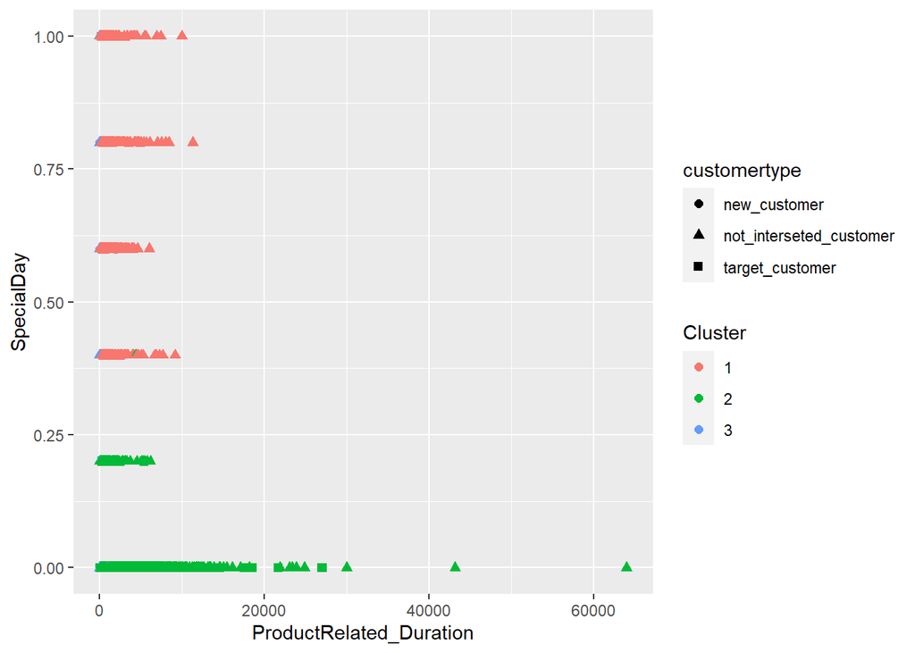

Using Hierarchical agglomerative clustering to cuts the tree into the groups by specifying the 3 groups.

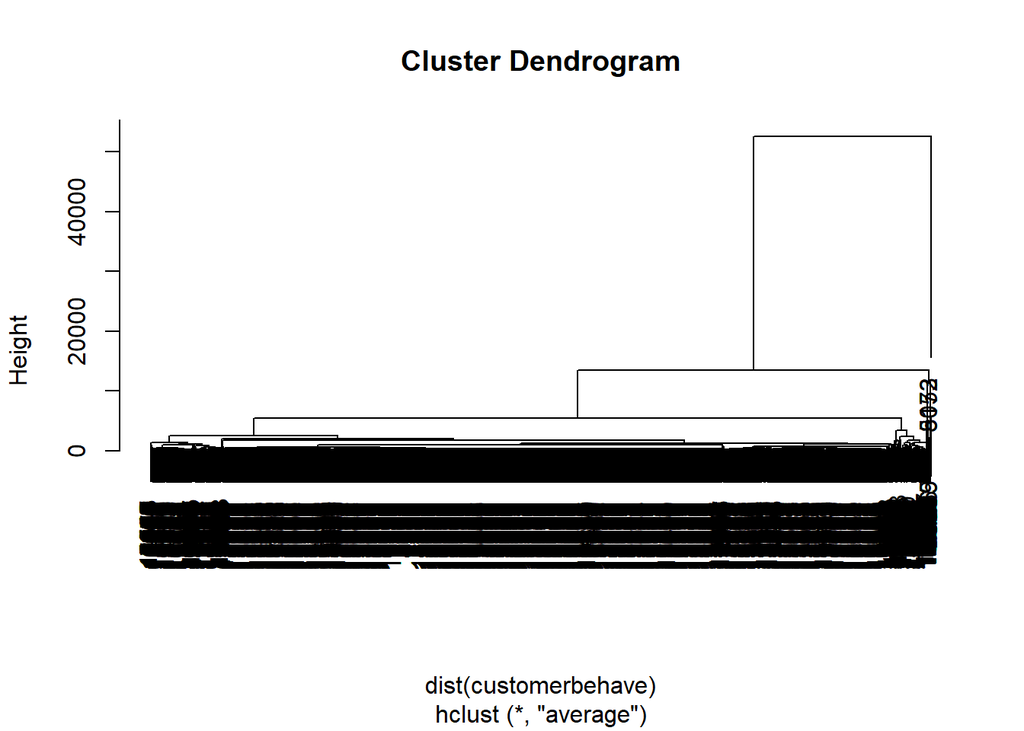

```r
# Use average link
library(cluster)
clusters <- hclust(dist(customerbehave),method="average") # average link
#Plot the dendogram
plot(clusters)
```

```r
# Create 3 clusters
cluster_cut <- cutree(clusters, 3)
# Compare the results


compare<- function(dat1,cluster,c,d,a,b){

print(table(cluster,dat1$customertype))

ggplot(dat1, aes(c, d,
 shape=customertype,
 colour = as.factor(cluster_kmean$cluster))) +
 geom_point(size=2) +
 labs(colour="Cluster")+labs( x = a , y= b )
}


compare(dat1,cluster_cut,dat1$ProductRelated_Duration,dat1$BounceRates,"ProductRelated_Duration","BounceRates")
```

```
##
## cluster new_customer not_interseted_customer target_customer
##       1         1272                    9079            1892
##       2            0                       1               0
##       3            0                       1               0
```

```r
compare(dat1,cluster_cut,dat1$Informational_Duration,dat1$BounceRates,"Informational_Duration","BounceRates")
```

```
##
## cluster new_customer not_interseted_customer target_customer
##       1         1272                    9079            1892
##       2            0                       1               0
##       3            0                       1               0
```

```r
compare(dat1,cluster_cut,dat1$Administrative,dat1$BounceRates,"Administrative","BounceRates")
```

```
##
## cluster new_customer not_interseted_customer target_customer
##       1         1272                    9079            1892
##       2            0                       1               0
##       3            0                       1               0
```

```r
compare(dat1,cluster_cut,dat1$ExitRates,dat1$BounceRates,"ExitRates","BounceRates")
```

```
##
## cluster new_customer not_interseted_customer target_customer
##       1         1272                    9079            1892
##       2            0                       1               0
##       3            0                       1               0
```

```r
compare(dat1,cluster_cut,dat1$ProductRelated,dat1$BounceRates,"ProductRelated","PageValuess")
```

```
##
## cluster new_customer not_interseted_customer target_customer
##       1         1272                    9079            1892
##       2            0                       1               0
##       3            0                       1               0
```

```r
compare(dat1,cluster_cut,dat1$Informational,dat1$BounceRates,"Informational","PageValues")
```

```
##
## cluster new_customer not_interseted_customer target_customer
##       1         1272                    9079            1892
##       2            0                       1               0
##       3            0                       1               0
```

```r
compare(dat1,cluster_cut,dat1$Administrative,dat1$BounceRates,"Administrative","PageValues")
```

```
##
## cluster new_customer not_interseted_customer target_customer
##       1         1272                    9079            1892
##       2            0                       1               0
##       3            0                       1               0
```

```r
compare(dat1,cluster_cut,dat1$ProductRelated_Duration,dat1$SpecialDay,"ProductRelated_Duration","SpecialDay")
```

```
##
## cluster new_customer not_interseted_customer target_customer
##       1         1272                    9079            1892
##       2            0                       1               0
##       3            0                       1               0
```

For Hierarchical agglomerative clustering, the graph showed some useful insight, but we compared the results of the methods based on the Silhouette plot and Dunn index and chose the best clusters method.

```r
# EM clustering

# use EMCluster library
library(EMCluster, quietly = TRUE)
# initialize and perform EM clustering iterations
ret <- init.EM(customerbehave, nclass = 3)

# assign cluster ID to each observation
ret.new <- assign.class(customerbehave, ret, return.all = FALSE)
str(ret.new)
```

```
## List of 2
##  $ nc   : int [1:3] 6009 242 5994
##  $ class: num [1:12245] 3 3 3 3 1 3 3 3 3 1 ...
```

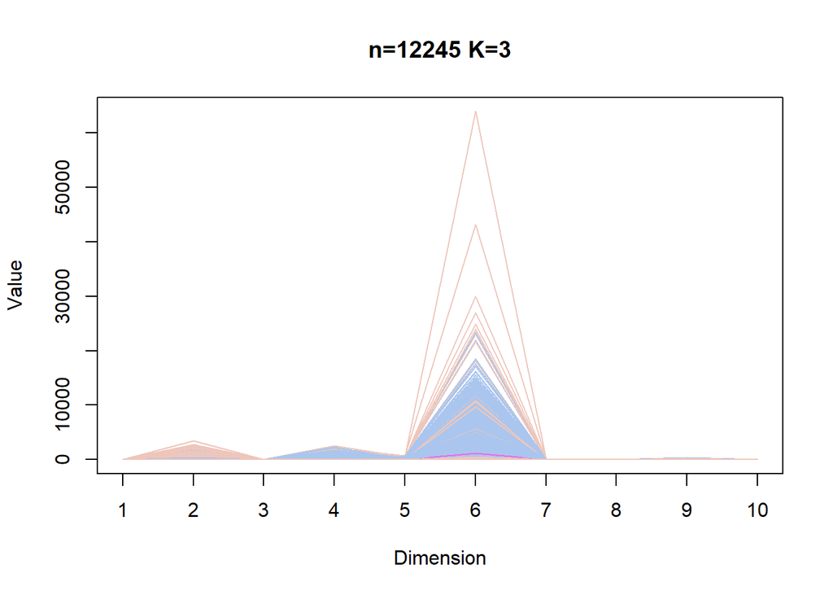

```r
# Plot results
plotem(ret,customerbehave)
```

```r
# Compare the result
compare(dat1,ret.new$class,dat1$ProductRelated_Duration,dat1$BounceRates,"ProductRelated_Duration","BounceRates")
```

```
##
## cluster new_customer not_interseted_customer target_customer
##       1          406                    4309            1294
##       2           22                     161              59
##       3          844                    4611             539
```

```r
compare(dat1,ret.new$class,dat1$Informational_Duration,dat1$BounceRates,"Informational_Duration","BounceRates")
```

```
##
## cluster new_customer not_interseted_customer target_customer
##       1          406                    4309            1294
##       2           22                     161              59
##       3          844                    4611             539
```

```r
compare(dat1,ret.new$class,dat1$Administrative,dat1$BounceRates,"Administrative","BounceRates")
```

```
##
## cluster new_customer not_interseted_customer target_customer
##       1          406                    4309            1294
##       2           22                     161              59
##       3          844                    4611             539
```

```r
compare(dat1,ret.new$class,dat1$ExitRates,dat1$BounceRates,"ExitRates","BounceRates")
```

```
##
## cluster new_customer not_interseted_customer target_customer
##       1          406                    4309            1294
##       2           22                     161              59
##       3          844                    4611             539
```

```r
compare(dat1,ret.new$class,dat1$ProductRelated,dat1$BounceRates,"ProductRelated","PageValuess")
```

```
##
## cluster new_customer not_interseted_customer target_customer
##       1          406                    4309            1294
##       2           22                     161              59
##       3          844                    4611             539
```

```r
compare(dat1,ret.new$class,dat1$Informational,dat1$BounceRates,"Informational","PageValues")
```

```
##
## cluster new_customer not_interseted_customer target_customer
##       1          406                    4309            1294
##       2           22                     161              59
##       3          844                    4611             539
```

```r
compare(dat1,ret.new$class,dat1$Administrative,dat1$BounceRates,"Administrative","PageValues")
```

```
##
## cluster new_customer not_interseted_customer target_customer
##       1          406                    4309            1294
##       2           22                     161              59
##       3          844                    4611             539
```

```r
compare(dat1,ret.new$class,dat1$ProductRelated_Duration,dat1$SpecialDay,"ProductRelated_Duration","SpecialDay")
```

```
##
## cluster new_customer not_interseted_customer target_customer
##       1          406                    4309            1294
##       2           22                     161              59
##       3          844                    4611             539
```

Density based clustering us epsilon is 2.5 and minimum points is 10 for finding the better clustering result.

```r
# use dbscan package
library(dbscan)
cluster_dbscan <- dbscan(customerbehave,eps=2.5,minPts =10)
cluster_dbscan
```

```
## DBSCAN clustering for 12245 objects.
## Parameters: eps = 2.5, minPts = 10
## The clustering contains 18 cluster(s) and 9862 noise points.
##
##    0    1    2    3    4    5    6    7    8    9   10   11   12   13   14   15
## 9862 1828  135   97   29   10   14   55   14   54   13   17   20   29   15   16
##   16   17   18
##   11   15   11
##
## Available fields: cluster, eps, minPts
```

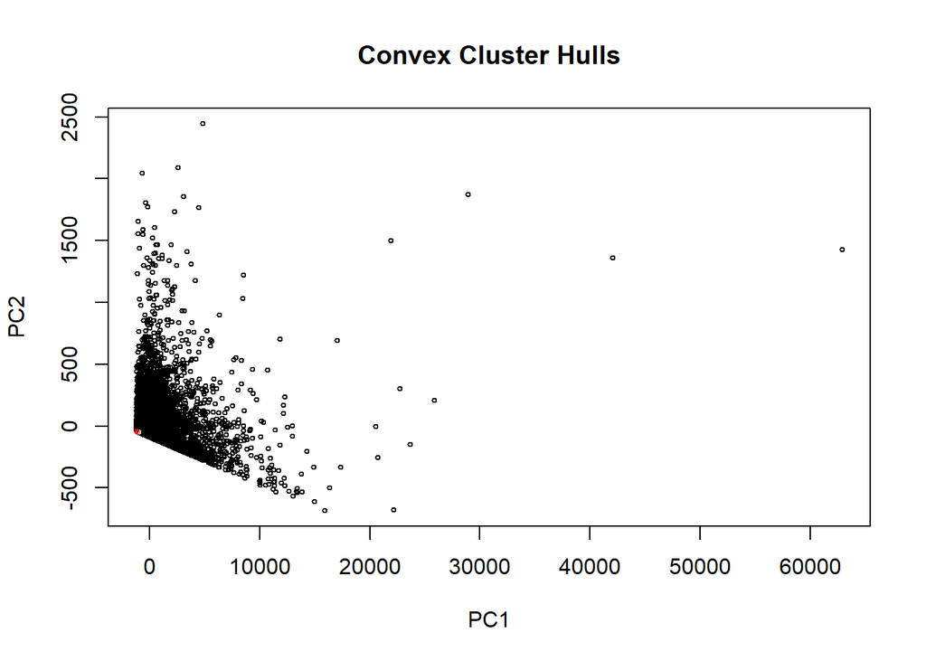

```r
# display the hull plot
hullplot(customerbehave,cluster_dbscan$cluster)
```

```r
# Compare the results


compare(dat1,cluster_dbscan$cluster,dat1$ProductRelated_Duration,dat1$BounceRates,"ProductRelated_Duration","BounceRates")
```

```
##
## cluster new_customer not_interseted_customer target_customer
##      0          1125                    6864            1873
##      1            92                    1723              13
##      2            11                     123               1
##      3             8                      86               3
##      4             4                      25               0
##      5             0                      10               0
##      6             1                      13               0
##      7             6                      49               0
##      8             1                      13               0
##      9             3                      51               0
##      10            2                      11               0
##      11            1                      16               0
##      12            2                      17               1
##      13            5                      24               0
##      14            1                      14               0
##      15            3                      13               0
##      16            1                      10               0
##      17            3                      11               1
##      18            3                       8               0
```

```r
compare(dat1,cluster_dbscan$cluster,dat1$Informational_Duration,dat1$BounceRates,"Informational_Duration","BounceRates")
```

```
##
## cluster new_customer not_interseted_customer target_customer
##      0          1125                    6864            1873
##      1            92                    1723              13
##      2            11                     123               1
##      3             8                      86               3
##      4             4                      25               0
##      5             0                      10               0
##      6             1                      13               0
##      7             6                      49               0
##      8             1                      13               0
##      9             3                      51               0
##      10            2                      11               0
##      11            1                      16               0
##      12            2                      17               1
##      13            5                      24               0
##      14            1                      14               0
##      15            3                      13               0
##      16            1                      10               0
##      17            3                      11               1
##      18            3                       8               0
```

```r
compare(dat1,cluster_dbscan$cluster,dat1$Administrative,dat1$BounceRates,"Administrative","BounceRates")
```

```
##
## cluster new_customer not_interseted_customer target_customer
##      0          1125                    6864            1873
##      1            92                    1723              13
##      2            11                     123               1
##      3             8                      86               3
##      4             4                      25               0
##      5             0                      10               0
##      6             1                      13               0
##      7             6                      49               0
##      8             1                      13               0
##      9             3                      51               0
##      10            2                      11               0
##      11            1                      16               0
##      12            2                      17               1
##      13            5                      24               0
##      14            1                      14               0
##      15            3                      13               0
##      16            1                      10               0
##      17            3                      11               1
##      18            3                       8               0
```

```r
compare(dat1,cluster_dbscan$cluster,dat1$ExitRates,dat1$BounceRates,"ExitRates","BounceRates")
```

```
##
## cluster new_customer not_interseted_customer target_customer
##      0          1125                    6864            1873
##      1            92                    1723              13
##      2            11                     123               1
##      3             8                      86               3
##      4             4                      25               0
##      5             0                      10               0
##      6             1                      13               0
##      7             6                      49               0
##      8             1                      13               0
##      9             3                      51               0
##      10            2                      11               0
##      11            1                      16               0
##      12            2                      17               1
##      13            5                      24               0
##      14            1                      14               0
##      15            3                      13               0
##      16            1                      10               0
##      17            3                      11               1
##      18            3                       8               0
```

```r
compare(dat1,cluster_dbscan$cluster,dat1$ProductRelated,dat1$BounceRates,"ProductRelated","PageValuess")
```

```
##
## cluster new_customer not_interseted_customer target_customer
##      0          1125                    6864            1873
##      1            92                    1723              13
##      2            11                     123               1
##      3             8                      86               3
##      4             4                      25               0
##      5             0                      10               0
##      6             1                      13               0
##      7             6                      49               0
##      8             1                      13               0
##      9             3                      51               0
##      10            2                      11               0
##      11            1                      16               0
##      12            2                      17               1
##      13            5                      24               0
##      14            1                      14               0
##      15            3                      13               0
##      16            1                      10               0
##      17            3                      11               1
##      18            3                       8               0
```

```r
compare(dat1,cluster_dbscan$cluster,dat1$Informational,dat1$BounceRates,"Informational","PageValues")
```

```
##
## cluster new_customer not_interseted_customer target_customer
##      0          1125                    6864            1873
##      1            92                    1723              13
##      2            11                     123               1
##      3             8                      86               3
##      4             4                      25               0
##      5             0                      10               0
##      6             1                      13               0
##      7             6                      49               0
##      8             1                      13               0
##      9             3                      51               0
##      10            2                      11               0
##      11            1                      16               0
##      12            2                      17               1
##      13            5                      24               0
##      14            1                      14               0
##      15            3                      13               0
##      16            1                      10               0
##      17            3                      11               1
##      18            3                       8               0
```

```r
compare(dat1,cluster_dbscan$cluster,dat1$Administrative,dat1$BounceRates,"Administrative","PageValues")
```

```
##
## cluster new_customer not_interseted_customer target_customer
##      0          1125                    6864            1873
##      1            92                    1723              13
##      2            11                     123               1
##      3             8                      86               3
##      4             4                      25               0
##      5             0                      10               0
##      6             1                      13               0
##      7             6                      49               0
##      8             1                      13               0
##      9             3                      51               0
##      10            2                      11               0
##      11            1                      16               0
##      12            2                      17               1
##      13            5                      24               0
##      14            1                      14               0
##      15            3                      13               0
##      16            1                      10               0
##      17            3                      11               1
##      18            3                       8               0
```

```r
compare(dat1,cluster_dbscan$cluster,dat1$ProductRelated_Duration,dat1$SpecialDay,"ProductRelated_Duration","SpecialDay")
```

```
##
## cluster new_customer not_interseted_customer target_customer
##      0          1125                    6864            1873
##      1            92                    1723              13
##      2            11                     123               1
##      3             8                      86               3
##      4             4                      25               0
##      5             0                      10               0
##      6             1                      13               0
##      7             6                      49               0
##      8             1                      13               0
##      9             3                      51               0
##      10            2                      11               0
##      11            1                      16               0
##      12            2                      17               1
##      13            5                      24               0
##      14            1                      14               0
##      15            3                      13               0
##      16            1                      10               0
##      17            3                      11               1
##      18            3                       8               0
```

After finishing four methods, we unsing clValid function for Dunn index ranking.

```r
library(clValid)
dunn(dist(customerbehave), cluster_kmean$cluster)
```

```
## [1] 5.812557e-07
```

```r
dunn(dist(customerbehave), cluster_cut)
```

```
## [1] 0.4379705
```

```r
dunn(dist(customerbehave), ret.new$class)
```

```
## [1] 4.381872e-05
```

```r
dunn(dist(customerbehave), cluster_dbscan$cluster)
```

```
## [1] 0.00592936
```

cluster_kmean$cluster = 5.812557e-07 cluster_cut = 0.4379705 ret.new$clas = 4.381872e-05 cluster_dbscan$cluster = 0.00592936

lets see the result of Silhouette coefficient, to know which methods are the best

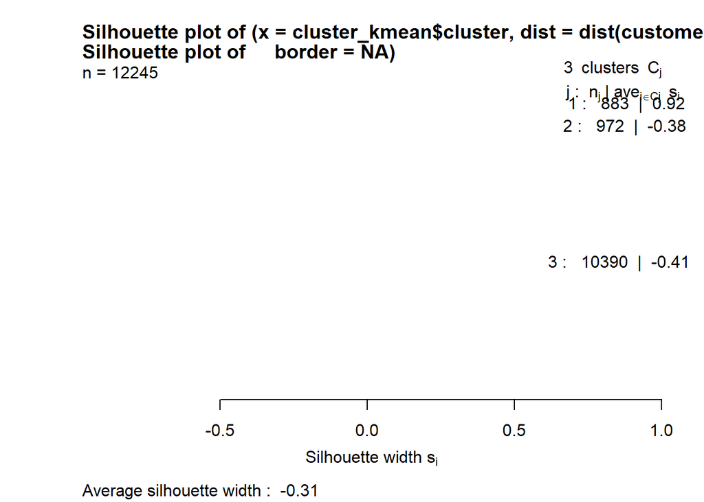

```r
library(cluster)
library(dplyr)
# compute the Silhouette information and plot the value for clusters

plot(silhouette(cluster_kmean$cluster, dist(customerbehave), col=1:3, border=NA))
```

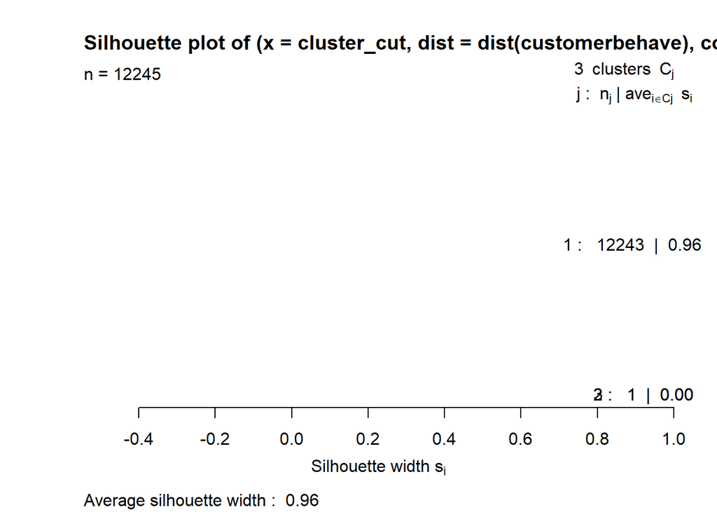

```r
plot(silhouette(cluster_cut, dist(customerbehave), col=1:3, border=NA))
```

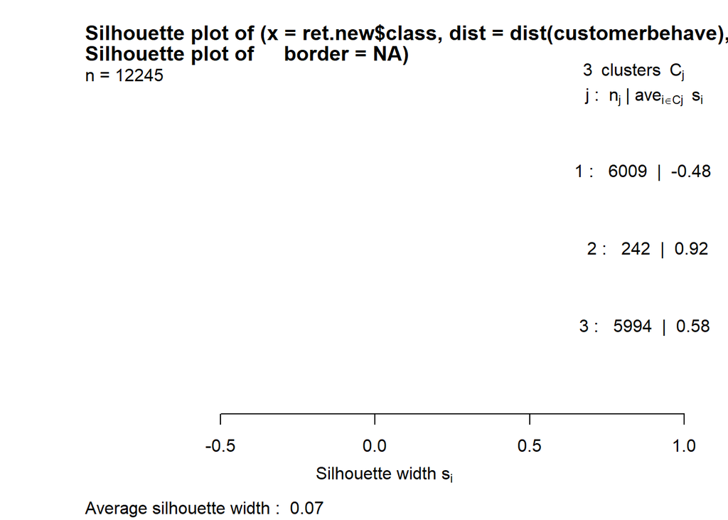

```r
plot(silhouette(ret.new$class, dist(customerbehave), col=1:3, border=NA))
```

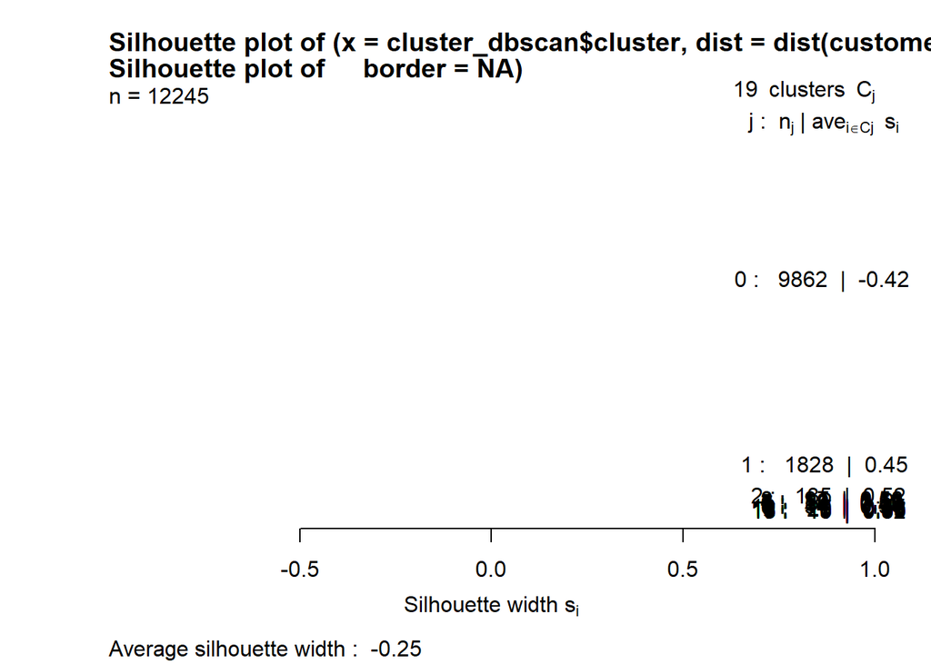

```r
plot(silhouette(cluster_dbscan$cluster, dist(customerbehave), col=1:3, border=NA))
```

```r
##silhouette(cluster_kmean$cluster,dist(customerbehave),border = NA)border = NA %>% plot
##silhouette(cluster_cut,dist(customerbehave),border = NA) %>% plot
##silhouette(ret.new$class,dist(customerbehave),border = NA) %>% plot
##silhouette(cluster_dbscan$cluster,dist(customerbehave),border = NA) %>% plot
```

Due to the Rstudio not successfully outputting the plot,it seems to be a PNG format problem. but still able to get the result of average silhouette, I am going ranking the output by average silhouette width: 1. Hierarchical clustering; 2. EM; 3. DBSCAN; and 4. k means. since the ranking of both silhouette width and the Dunn index ranking no.1 is Hierarchical clustering, I highly believe Hierarchical clustering is the most suitable clusting for my report. cluster_kmean$cluster = -0.31 cluster_cut = 0.96 ret.new$clas = 0.07 cluster_dbscan$cluster = -0.25

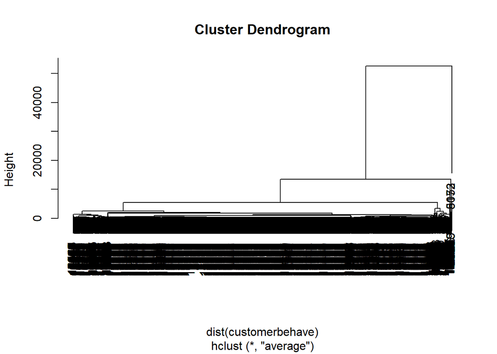

```r
library(cluster)
clusters <- hclust(dist(customerbehave),method="average") # average link
#Plot the dendogram
plot(clusters)
```

```r
# Create 3 clusters
cluster_cut <- cutree(clusters, 3)
# Compare the results


compare<- function(dat1,cluster,c,d,a,b){

print(table(cluster,dat1$customertype))

ggplot(dat1, aes(c, d,
 shape=customertype,
 colour = as.factor(cluster_kmean$cluster))) +
 geom_point(size=2) +
 labs(colour="Cluster")+labs( x = a , y= b )
}
```

ProductRelated_Duration vs BounceRates cluster result and the raw result After clustering. We can see that higher BouncerRates usually the not interested customer, target customer usually have a lower BounceRates and spend more time on ProductRelated_Duration, It means that if we have improved features like better user interface or graphic. it may gain more target customers since BounceRates are lower.

```r
compare(dat1,cluster_cut,dat1$ProductRelated_Duration,dat1$BounceRates,"ProductRelated_Duration","BounceRates")
```

```
##
## cluster new_customer not_interseted_customer target_customer
##       1         1272                    9079            1892
##       2            0                       1               0
##       3            0                       1               0
```

```r
o(dat1,dat1$ProductRelated_Duration,dat1$BounceRates,"ProductRelated_Duration","BounceRates")
```

[output not shown]

Informational_Duration vs BounceRates cluster result and the raw result After clustering. We can see that higher BouncerRates usually the not interested customer, target customer usually have a lower BounceRates and spend more time on Informational_Duration, It means that if we have a better content form Informational page,we may gain more target customers. Also the new_customer doesn’t get the result of very low Informational page views.

```r
compare(dat1,cluster_cut,dat1$Informational_Duration,dat1$BounceRates,"Informational_Duration","BounceRates")
```

```
##
## cluster new_customer not_interseted_customer target_customer
##       1         1272                    9079            1892
##       2            0                       1               0
##       3            0                       1               0
```

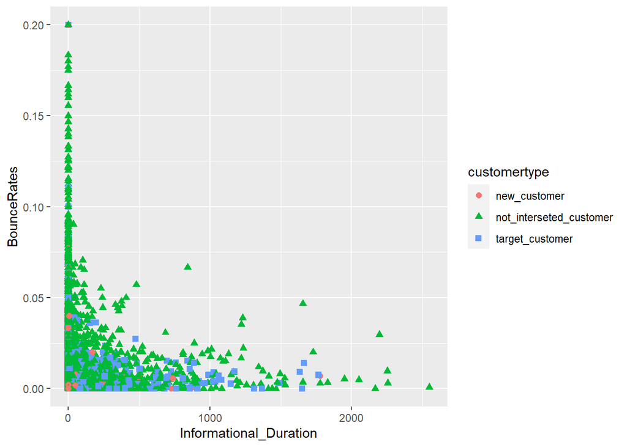

```r
o(dat1,dat1$Informational_Duration,dat1$BounceRates,"Informational_Duration","BounceRates")
```

Administrative vs BounceRates cluster result and the raw result After clustering. we can see that Administrative page views are target customers. Its mean target customer may spend more time handling Administrative pages, If we have a feature on the button from the web that can let the customer fast entry to the product related page, which is able to increase sales.

```r
compare(dat1,cluster_cut,dat1$Administrative,dat1$BounceRates,"Administrative","BounceRates")
```

```
##
## cluster new_customer not_interseted_customer target_customer
##       1         1272                    9079            1892
##       2            0                       1               0
##       3            0                       1               0
```

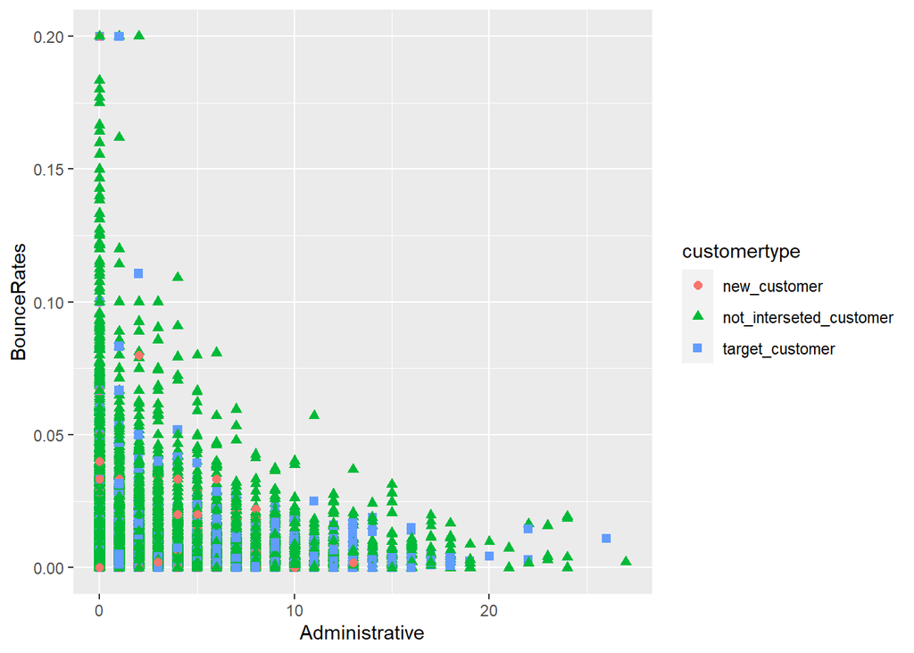

```r
o(dat1,dat1$Administrative,dat1$BounceRates,"Administrative","BounceRates")
```

Also BounceRates and Exitrate are higher in not_inteseted_customer, if we can make a previous user rate include BounceRates and Exit Rate. If the BounceRates and Exit Rate, we likely to offer more advertising spend on that user.

```r
compare(dat1,cluster_cut,dat1$ExitRates,dat1$BounceRates,"ExitRates","BounceRates")
```

```
##
## cluster new_customer not_interseted_customer target_customer
##       1         1272                    9079            1892
##       2            0                       1               0
##       3            0                       1               0
```

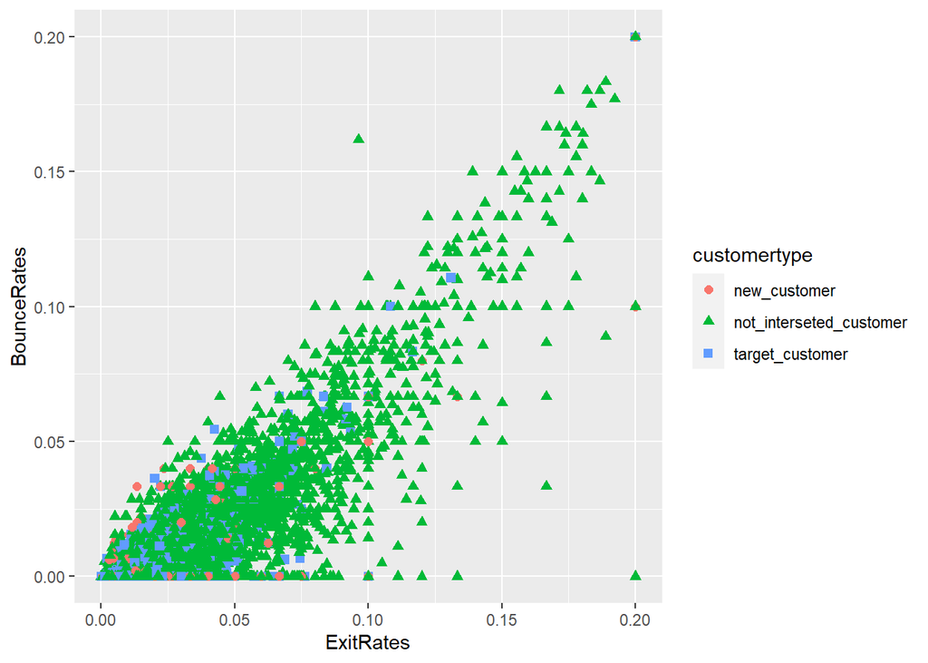

```r
o(dat1,dat1$ExitRates,dat1$BounceRates,"ExitRates","BounceRates")
```

```r
compare(dat1,cluster_cut,dat1$ProductRelated,dat1$BounceRates,"ProductRelated","PageValuess")
```

```
##
## cluster new_customer not_interseted_customer target_customer
##       1         1272                    9079            1892
##       2            0                       1               0
##       3            0                       1               0
```

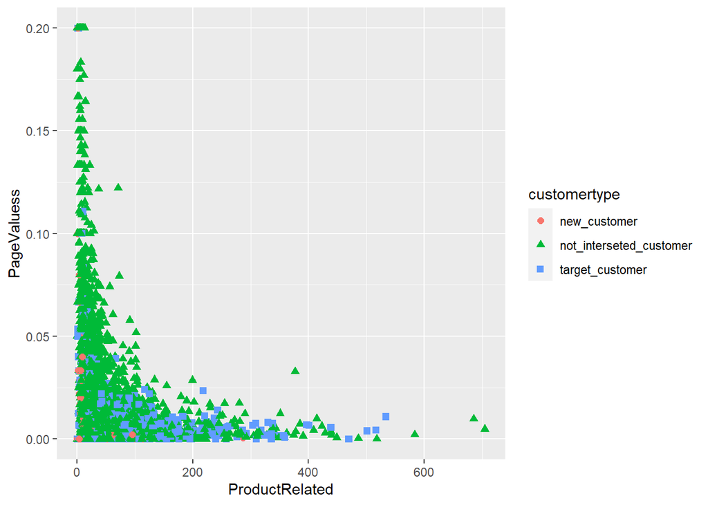

```r
o(dat1,dat1$ProductRelated,dat1$BounceRates,"ProductRelated","PageValuess")
```

```r
compare(dat1,cluster_cut,dat1$Informational,dat1$PageValues,"Informational","PageValues")
```

```
##
## cluster new_customer not_interseted_customer target_customer
##       1         1272                    9079            1892
##       2            0                       1               0
##       3            0                       1               0
```

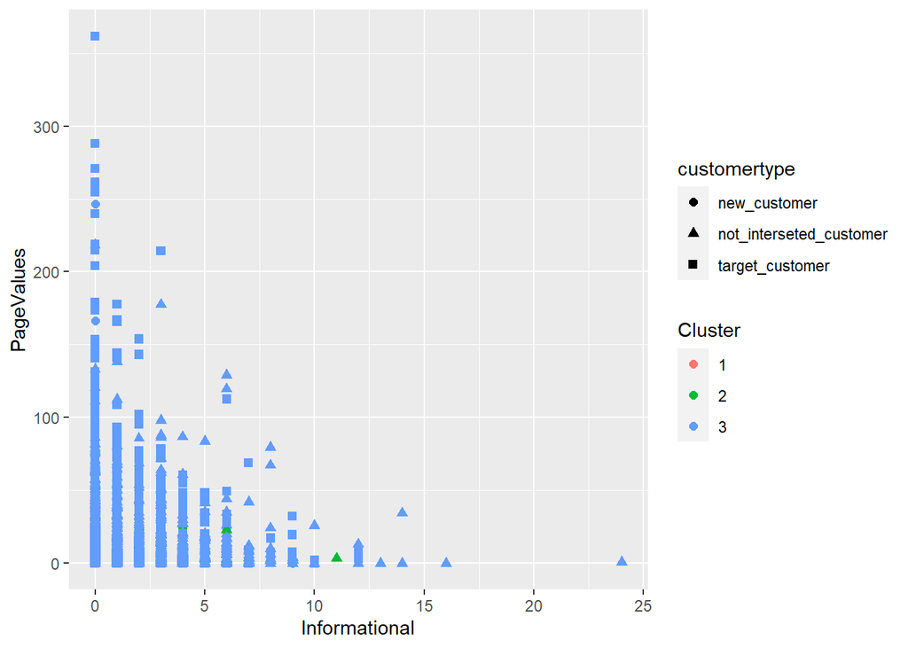

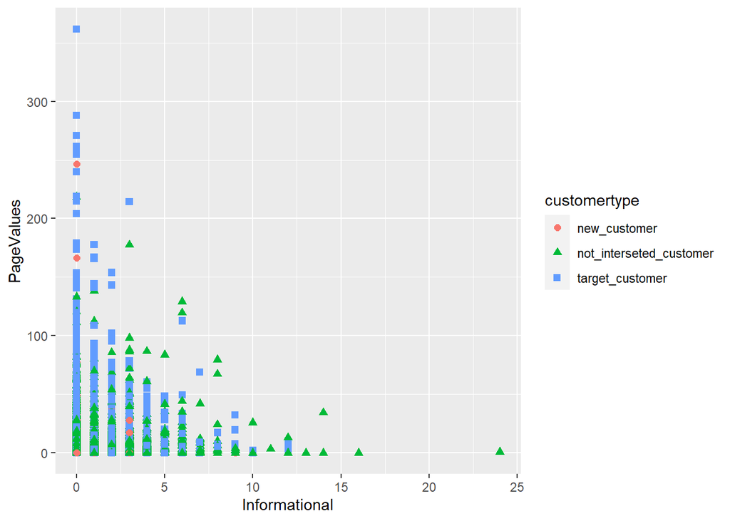

```r
o(dat1,dat1$Informational,dat1$PageValues,"Informational","PageValues")
```

```r
compare(dat1,cluster_cut,dat1$Administrative,dat1$BounceRates,"Administrative","PageValues")
```

```
##
## cluster new_customer not_interseted_customer target_customer
##       1         1272                    9079            1892
##       2            0                       1               0
##       3            0                       1               0
```

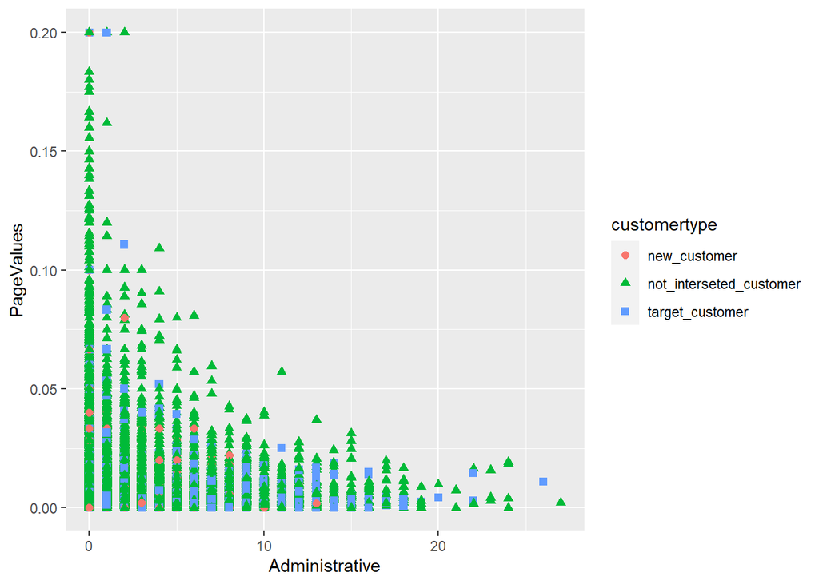

```r
o(dat1,dat1$Administrative,dat1$BounceRates,"Administrative","PageValues")
```

```r
compare(dat1,cluster_cut,dat1$ProductRelated_Duration,dat1$SpecialDay,"ProductRelated_Duration","SpecialDay")
```

```
##
## cluster new_customer not_interseted_customer target_customer
##       1         1272                    9079            1892
##       2            0                       1               0
##       3            0                       1               0
```

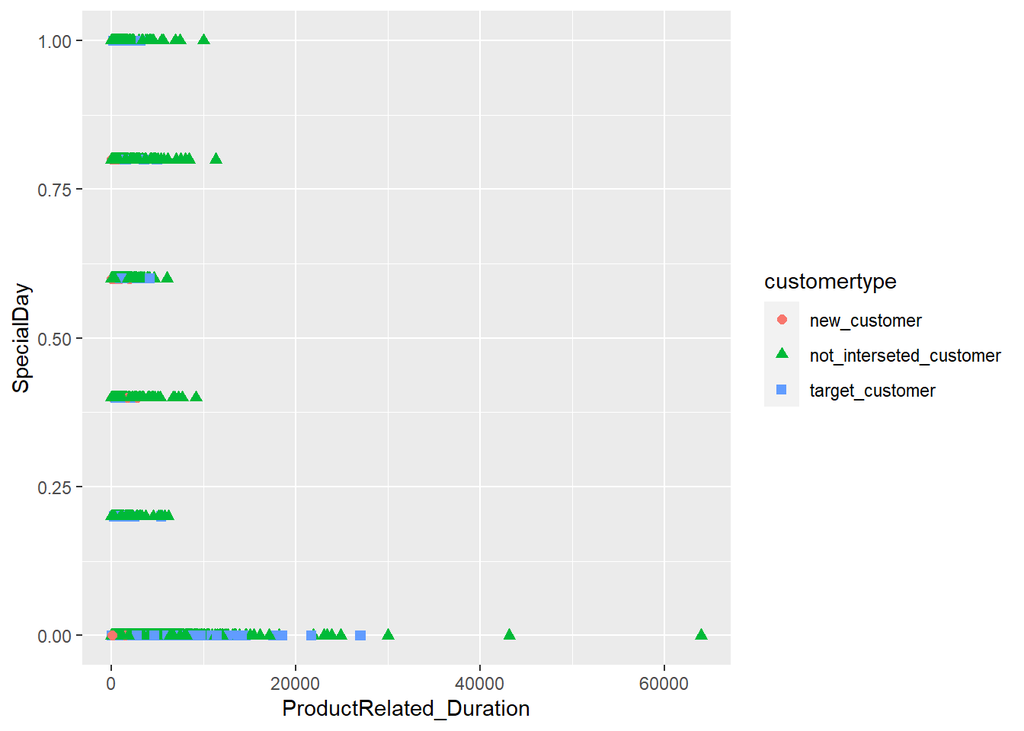

```r
o(dat1,dat1$ProductRelated_Duration,dat1$SpecialDay,"ProductRelated_Duration","SpecialDay")
```

Since we got so much useful insight for customer behaviour to predict our target customer. We can use the behaviour of the customer to define his/her type. We can also use Kmeans centers for seeing the output or the clustmer of customers behave.

```r
cluster_kmean <- kmeans(customerbehave,3)
cluster_kmean$centers
```

```
##   Administrative Administrative_Duration Informational Informational_Duration
## 1       4.330289               154.97350     1.1765601               84.84446
## 2       7.475728               296.79870     2.7427184              266.92191
## 3       1.822209                62.03526     0.3287644               20.04738
##   ProductRelated ProductRelated_Duration BounceRates  ExitRates PageValues
## 1       77.81786               3355.0877 0.007142700 0.02169103   7.973463
## 2      236.17476              10892.2713 0.005709582 0.01946272   4.543319
## 3       18.68872                578.6701 0.025336553 0.04757058   5.404909
##   SpecialDay
## 1 0.05083714
## 2 0.03106796
## 3 0.06464044
```

```r
print(table(cluster_kmean$cluster,dat1$customertype))
```

```
##
##     new_customer not_interseted_customer target_customer
##   1           58                    1420             493
##   2            1                     135              70
##   3         1213                    7526            1329
```

K-means are e clusters with clustering the nearest mean, if its a categorical variable which does not have any mean, It will cause error in R ,since R can only read K-means in continuous variable, It is not able to run the R code property. If the situation is, we must use mixed data types both numerical and categorical variables so that we are able to gain more insight like the online shoppers for buying intention dataset. We need to use data visualization like a qq plot to show clusters of k-means also adding shape by categorical variables you want to investigate. Using categorical variables out in a kmean$centers table also is a good way to explore data during clustering.